# ARIMA, SARIMA and Forecasting with Python

###### By Rohit Pardasani

```python
import statsmodels.tsa.stattools as ts
import numpy as np
import pandas as pd
```

```
Global Temperature
Total Length :  136
```

|  | Time | Val |
| --- | --- | --- |
| 0 | 1880 | -0.20 |
| 1 | 1881 | -0.11 |
| 2 | 1882 | -0.10 |
| 3 | 1883 | -0.20 |
| 4 | 1884 | -0.28 |
| ... | ... | ... |
| 131 | 2011 | 0.60 |
| 132 | 2012 | 0.63 |
| 133 | 2013 | 0.66 |
| 134 | 2014 | 0.75 |
| 135 | 2015 | 0.87 |

136 rows × 2 columns

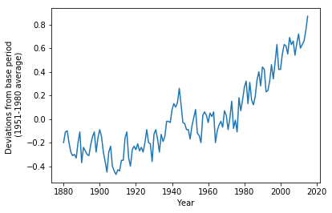

```python
import pandas as pd
import numpy as np
import matplotlib.pyplot as plt
pd.set_option('display.max_rows', 10)
df = pd.read_csv('globtemp.csv')
print("Global Temperature")
print('Total Length : ',len(df))
display(df)
plt.plot(df.Time.values, df.Val.values)
plt.xlabel("Year")
plt.ylabel("Deviations from base period \n (1951-1980 average)")
plt.show()
```

## Fitting ARIMA on Global Temp

There is an increasing trend.  
Can we do away with this trend with differencing.

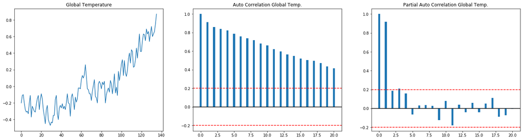

```python
import matplotlib.pyplot as plt
from statsmodels.tsa import arima_process
x = df.Val.values
plt.figure(figsize=(24,6))
plt.subplot(1,3,1)
plt.title('Global Temperature')
plt.plot(x)

plt.subplot(1,3,2)
acorf_x = ts.acf(x,fft=False,adjusted=False,nlags=20)
plt.bar(x=np.arange(len(acorf_x)),height=acorf_x,width=0.3)
plt.axhline(y=0,color='black')
plt.axhline(y=0.2,color='red',linestyle='--')
plt.axhline(y=-0.2,color='red',linestyle='--')
plt.title("Auto Correlation Global Temp.")

plt.subplot(1,3,3)
apcorf_x = ts.pacf(x,nlags=20)
plt.bar(x=np.arange(len(apcorf_x)),height=apcorf_x,width=0.3)
plt.axhline(y=0,color='black')
plt.axhline(y=0.2,color='red',linestyle='--')
plt.axhline(y=-0.2,color='red',linestyle='--')
plt.title("Partial Auto Correlation Global Temp.")

#plt.plot(x)
plt.show()
```

ACF is decaying very slowly. Indicates that differencing might be required

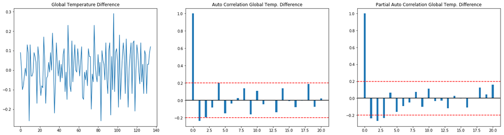

```python
xdiff = []
for i in range(len(x)-1):
    xdiff.append(x[i+1]-x[i])
plt.figure(figsize=(24,6))
plt.subplot(1,3,1)
plt.title('Global Temperature Difference')
plt.plot(xdiff)

plt.subplot(1,3,2)
acorf_x = ts.acf(xdiff,fft=False,adjusted=False,nlags=20)
plt.bar(x=np.arange(len(acorf_x)),height=acorf_x,width=0.3)
plt.axhline(y=0,color='black')
plt.axhline(y=0.2,color='red',linestyle='--')
plt.axhline(y=-0.2,color='red',linestyle='--')
plt.title("Auto Correlation Global Temp. Difference")

plt.subplot(1,3,3)
apcorf_x = ts.pacf(xdiff,nlags=20)
plt.bar(x=np.arange(len(apcorf_x)),height=apcorf_x,width=0.3)
plt.axhline(y=0,color='black')
plt.axhline(y=0.2,color='red',linestyle='--')
plt.axhline(y=-0.2,color='red',linestyle='--')
plt.title("Partial Auto Correlation Global Temp. Difference")

#plt.plot(x)
plt.show()
```

Suggests that d=1 should be helpful  
Order of AR can be taken 3 (p=3)  
Order of MA can be taken 2 (q=2)

```python
from statsmodels.tsa.arima.model import ARIMA
x = df.Val.values
models = []
results = []
orders = []
for d in range(2):
    for p in range(4):
        for q in range(3):
            mod = ARIMA(endog=x, order=(p,d,q))
            res = mod.fit()
            models.append(mod)
            results.append(res)
            orders.append((p,d,q))
            print('Order p=%d,d=%d,q=%d: AIC : %f , Parameters : p = %s q = %s"'%(p,d,q,np.round(res.aic,4),str(res.polynomial_ar),str(res.polynomial_ma)))
```

```
Order p=0,d=0,q=0: AIC : 76.750100 , Parameters : p = [1.] q = [1.]"
Order p=0,d=0,q=1: AIC : -35.350700 , Parameters : p = [1.] q = [1.        0.7236474]"
Order p=0,d=0,q=2: AIC : -105.949200 , Parameters : p = [1.] q = [1.         1.05936733 0.63060095]"
Order p=1,d=0,q=0: AIC : -211.017400 , Parameters : p = [ 1.         -0.95710106] q = [1.]"
Order p=1,d=0,q=1: AIC : -222.430200 , Parameters : p = [ 1.         -0.99125309] q = [ 1.         -0.45239065]"
Order p=1,d=0,q=2: AIC : -225.843500 , Parameters : p = [ 1.         -0.99444502] q = [ 1.         -0.3600536  -0.18674071]"
Order p=2,d=0,q=0: AIC : -215.255500 , Parameters : p = [ 1.         -0.75490877 -0.21534548] q = [1.]"
Order p=2,d=0,q=1: AIC : -211.693100 , Parameters : p = [ 1.         -0.00609241 -0.91915839] q = [1.         0.90254193]"
```

```
Order p=2,d=0,q=2: AIC : -219.192700 , Parameters : p = [ 1.         -0.00269586 -0.97818773] q = [ 1.          0.53777041 -0.42600475]"
Order p=3,d=0,q=0: AIC : -221.992300 , Parameters : p = [ 1.         -0.69792916 -0.02980206 -0.25252776] q = [1.]"
Order p=3,d=0,q=1: AIC : -224.644700 , Parameters : p = [ 1.         -1.20693881  0.36334854 -0.15244391] q = [ 1.         -0.56592604]"
```

```
Order p=3,d=0,q=2: AIC : -222.081700 , Parameters : p = [ 1.         -0.45907449 -0.90068316  0.36348509] q = [ 1.          0.16169236 -0.64944291]"
Order p=0,d=1,q=0: AIC : -213.707300 , Parameters : p = [1.] q = [1.]"
Order p=0,d=1,q=1: AIC : -227.162500 , Parameters : p = [1.] q = [ 1.         -0.46248957]"
Order p=0,d=1,q=2: AIC : -230.758100 , Parameters : p = [1.] q = [ 1.         -0.36336508 -0.18903961]"
Order p=1,d=1,q=0: AIC : -219.086800 , Parameters : p = [1.         0.23193559] q = [1.]"
Order p=1,d=1,q=1: AIC : -229.621200 , Parameters : p = [ 1.         -0.31297157] q = [ 1.        -0.6969147]"
Order p=1,d=1,q=2: AIC : -228.776900 , Parameters : p = [ 1.        -0.0385967] q = [ 1.         -0.39817028 -0.17418207]"
Order p=2,d=1,q=0: AIC : -226.474700 , Parameters : p = [1.         0.2944477  0.26028555] q = [1.]"
Order p=2,d=1,q=1: AIC : -229.607400 , Parameters : p = [ 1.         -0.19516809  0.16127784] q = [ 1.         -0.55057336]"
Order p=2,d=1,q=2: AIC : -227.711500 , Parameters : p = [ 1.         -0.30891797  0.21313702] q = [ 1.         -0.66525162  0.09407704]"
Order p=3,d=1,q=0: AIC : -231.304400 , Parameters : p = [1.         0.35378941 0.32911896 0.22331024] q = [1.]"
Order p=3,d=1,q=1: AIC : -231.625200 , Parameters : p = [1.         1.07716953 0.52790849 0.35649118] q = [1.         0.79307838]"
Order p=3,d=1,q=2: AIC : -227.970100 , Parameters : p = [1.         0.82215063 0.02469346 0.20140889] q = [ 1.          0.48676815 -0.5021449 ]"
```

Keeping in mind the parsimony principle, Order p=0,d=1,q=2 can be preferred over others

### Let's try to forecast global temp. using ARIMA model

Not going by the standard way as this is just an experiment  
We have already decided the order of model  
We use those parameters and fit model on half the series  
Remaining half series we predict using the model.

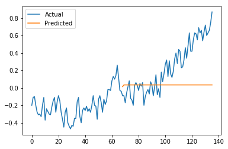

```
Model has failed to make a good long term prediction
```

```python
x = df.Val.values
xTrain = x[0:68]
xTest = x[68:136]
mod = ARIMA(endog=xTrain, order=(0,1,2))
res = mod.fit()
prediction = res.forecast(steps=68)
t = np.arange(len(x))
plt.plot(t,x,label='Actual')
plt.plot(t[68:136],prediction,label='Predicted')
plt.legend()
plt.show()
print('Model has failed to make a good long term prediction')
```

ARIMA models are generally good for one step forecast. Let's try that.

```
Test RMSE: 0.109
```

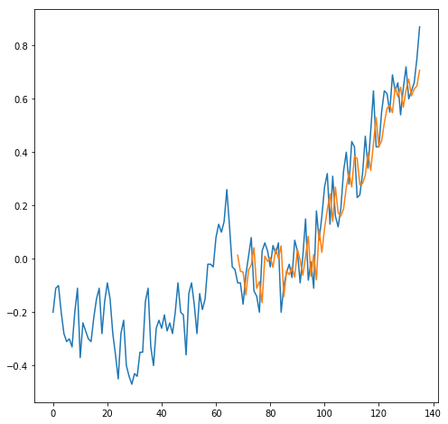

```python
from sklearn.metrics import mean_squared_error
from math import sqrt
history = [val for val in xTrain]
predictions = list()
# walk-forward validation
plt.figure(figsize=(8,8))
for ind in range(len(xTest)):
    model = ARIMA(history, order=(0,1,2))
    model_fit = model.fit()
    output = model_fit.forecast()
    yhat = output[0]
    predictions.append(yhat)
    obs = xTest[ind]
    history.append(obs)
    #print('predicted=%f, expected=%f' % (yhat, obs))
# evaluate forecasts
rmse = sqrt(mean_squared_error(xTest, predictions))
print('Test RMSE: %.3f' % rmse)
# plot forecasts against actual outcomes
plt.plot(t,x,label='Actual')
plt.plot(t[68:136],predictions,label='Predicted')
plt.show()
```

Somewhat better, but we are just making one step prediction.

## SARIMA

```
Johnson & Johnson Quarterly Earning
Total Quarters :  84
```

|  | Year-Qtr | Time | Val |
| --- | --- | --- | --- |
| 0 | 1960-Q1 | 1960.00 | 0.71 |
| 1 | 1960-Q2 | 1960.25 | 0.63 |
| 2 | 1960-Q3 | 1960.50 | 0.85 |
| 3 | 1960-Q4 | 1960.75 | 0.44 |
| 4 | 1961-Q1 | 1961.00 | 0.61 |
| ... | ... | ... | ... |
| 79 | 1979-Q4 | 1979.75 | 9.99 |
| 80 | 1980-Q1 | 1980.00 | 16.20 |
| 81 | 1980-Q2 | 1980.25 | 14.67 |
| 82 | 1980-Q3 | 1980.50 | 16.02 |
| 83 | 1980-Q4 | 1980.75 | 11.61 |

84 rows × 3 columns

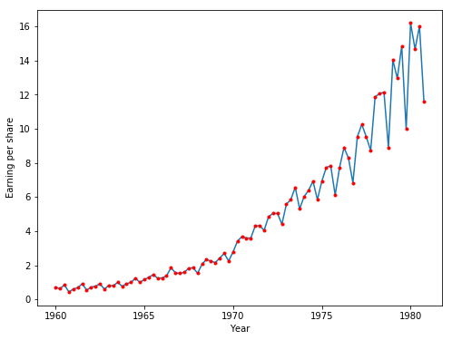

```python
import pandas as pd
import numpy as np
import matplotlib.pyplot as plt
pd.set_option('display.max_rows', 10)
df = pd.read_csv('JJ.csv')
print("Johnson & Johnson Quarterly Earning")
print('Total Quarters : ',len(df))
display(df)
plt.figure(figsize=(8,6))
plt.plot(df.Time.values, df.Val.values,marker='.',markerfacecolor='red', markeredgecolor='red')
plt.ylabel('Earning per share')
plt.xlabel('Year')
plt.show()
```

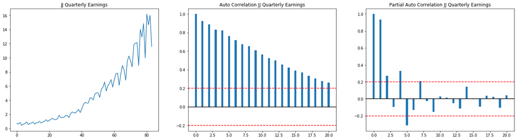

```python
import statsmodels.tsa.stattools as ts
from statsmodels.tsa import arima_process
x = df.Val.values
plt.figure(figsize=(24,6))
plt.subplot(1,3,1)
plt.title('JJ Quarterly Earnings')
plt.plot(x)

plt.subplot(1,3,2)
acorf_x = ts.acf(x,fft=False,adjusted=False,nlags=20)
plt.bar(x=np.arange(len(acorf_x)),height=acorf_x,width=0.3)
plt.axhline(y=0,color='black')
plt.axhline(y=0.2,color='red',linestyle='--')
plt.axhline(y=-0.2,color='red',linestyle='--')
plt.title("Auto Correlation JJ Quarterly Earnings")

plt.subplot(1,3,3)
apcorf_x = ts.pacf(x,nlags=20)
plt.bar(x=np.arange(len(apcorf_x)),height=apcorf_x,width=0.3)
plt.axhline(y=0,color='black')
plt.axhline(y=0.2,color='red',linestyle='--')
plt.axhline(y=-0.2,color='red',linestyle='--')
plt.title("Partial Auto Correlation JJ Quarterly Earnings")

#plt.plot(x)
plt.show()
```

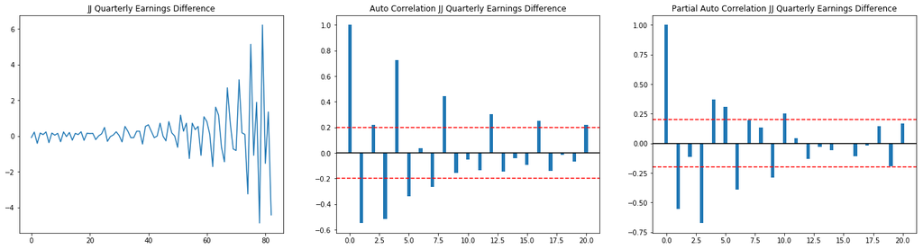

```python
xdiff = []
for i in range(len(x)-1):
    xdiff.append(x[i+1]-x[i])
plt.figure(figsize=(24,6))
plt.subplot(1,3,1)
plt.title('JJ Quarterly Earnings Difference')
plt.plot(xdiff)

plt.subplot(1,3,2)
acorf_x = ts.acf(xdiff,fft=False,adjusted=False,nlags=20)
plt.bar(x=np.arange(len(acorf_x)),height=acorf_x,width=0.3)
plt.axhline(y=0,color='black')
plt.axhline(y=0.2,color='red',linestyle='--')
plt.axhline(y=-0.2,color='red',linestyle='--')
plt.title("Auto Correlation JJ Quarterly Earnings Difference")

plt.subplot(1,3,3)
apcorf_x = ts.pacf(xdiff,nlags=20)
plt.bar(x=np.arange(len(apcorf_x)),height=apcorf_x,width=0.3)
plt.axhline(y=0,color='black')
plt.axhline(y=0.2,color='red',linestyle='--')
plt.axhline(y=-0.2,color='red',linestyle='--')
plt.title("Partial Auto Correlation JJ Quarterly Earnings Difference")

#plt.plot(x)
plt.show()
```

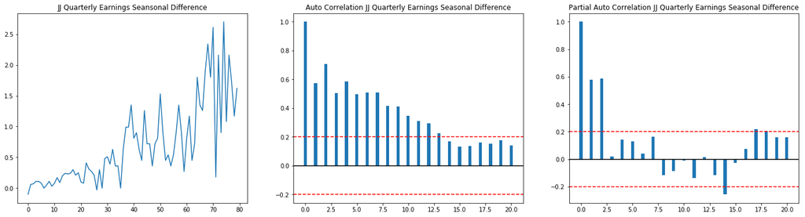

```python
xdiff = []
for i in range(len(x)-4):
    xdiff.append(x[i+4]-x[i])
plt.figure(figsize=(24,6))
plt.subplot(1,3,1)
plt.title('JJ Quarterly Earnings Seansonal Difference')
plt.plot(xdiff)

plt.subplot(1,3,2)
acorf_x = ts.acf(xdiff,fft=False,adjusted=False,nlags=20)
plt.bar(x=np.arange(len(acorf_x)),height=acorf_x,width=0.3)
plt.axhline(y=0,color='black')
plt.axhline(y=0.2,color='red',linestyle='--')
plt.axhline(y=-0.2,color='red',linestyle='--')
plt.title("Auto Correlation JJ Quarterly Earnings Seasonal Difference")

plt.subplot(1,3,3)
apcorf_x = ts.pacf(xdiff,nlags=20)
plt.bar(x=np.arange(len(apcorf_x)),height=apcorf_x,width=0.3)
plt.axhline(y=0,color='black')
plt.axhline(y=0.2,color='red',linestyle='--')
plt.axhline(y=-0.2,color='red',linestyle='--')
plt.title("Partial Auto Correlation JJ Quarterly Earnings Seasonal Difference")

#plt.plot(x)
plt.show()
```

#### Differencing Log

$r_t = log(X_t) - log(X_{t-1})$

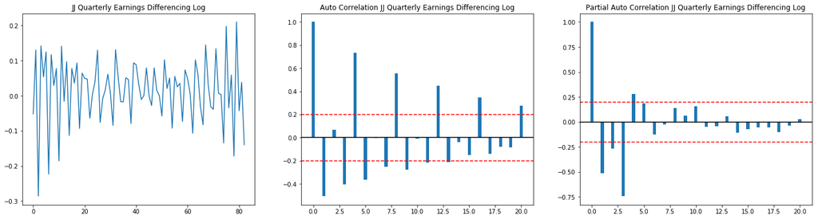

```python
import math
xdiff = []
for i in range(len(x)-1):
    xdiff.append(math.log10(x[i+1])-math.log10(x[i]))
plt.figure(figsize=(24,6))
plt.subplot(1,3,1)
plt.title('JJ Quarterly Earnings Differencing Log')
plt.plot(xdiff)

plt.subplot(1,3,2)
acorf_x = ts.acf(xdiff,fft=False,adjusted=False,nlags=20)
plt.bar(x=np.arange(len(acorf_x)),height=acorf_x,width=0.3)
plt.axhline(y=0,color='black')
plt.axhline(y=0.2,color='red',linestyle='--')
plt.axhline(y=-0.2,color='red',linestyle='--')
plt.title("Auto Correlation JJ Quarterly Earnings Differencing Log")

plt.subplot(1,3,3)
apcorf_x = ts.pacf(xdiff,nlags=20)
plt.bar(x=np.arange(len(apcorf_x)),height=apcorf_x,width=0.3)
plt.axhline(y=0,color='black')
plt.axhline(y=0.2,color='red',linestyle='--')
plt.axhline(y=-0.2,color='red',linestyle='--')
plt.title("Partial Auto Correlation JJ Quarterly Earnings Differencing Log")

#plt.plot(x)
plt.show()
```

#### Followed by seasonal differencing

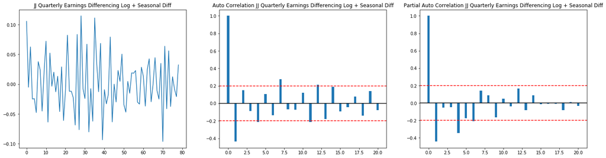

```python
import math
xdiffs = []
for i in range(len(xdiff)-4):
    xdiffs.append(xdiff[i+4]-xdiff[i])
plt.figure(figsize=(24,6))
plt.subplot(1,3,1)
plt.title('JJ Quarterly Earnings Differencing Log + Seasonal Diff')
plt.plot(xdiffs)

plt.subplot(1,3,2)
acorf_x = ts.acf(xdiffs,fft=False,adjusted=False,nlags=20)
plt.bar(x=np.arange(len(acorf_x)),height=acorf_x,width=0.3)
plt.axhline(y=0,color='black')
plt.axhline(y=0.2,color='red',linestyle='--')
plt.axhline(y=-0.2,color='red',linestyle='--')
plt.title("Auto Correlation JJ Quarterly Earnings Differencing Log + Seasonal Diff")

plt.subplot(1,3,3)
apcorf_x = ts.pacf(xdiffs,nlags=20)
plt.bar(x=np.arange(len(apcorf_x)),height=apcorf_x,width=0.3)
plt.axhline(y=0,color='black')
plt.axhline(y=0.2,color='red',linestyle='--')
plt.axhline(y=-0.2,color='red',linestyle='--')
plt.title("Partial Auto Correlation JJ Quarterly Earnings Differencing Log + Seasonal Diff")

#plt.plot(x)
plt.show()
```

```python
import statsmodels.tsa.stattools as ts
from statsmodels.tsa.statespace.sarimax import SARIMAX
from statsmodels.tsa import arima_process
x = df.Val.values
logx = np.log10(x)
d = 1
D = 1
S = 4
for p in range(2):
    for q in range(2):
        for P in range(2):
            for Q in range(2):
                mod = SARIMAX(endog=logx, order=(p,d,q), seasonal_order=(P, D, Q, S))
                res = mod.fit()
                print('Order p=%d,d=%d,q=%d, Seasonal Order P=%d,D=%d,Q=%d,S=%d: AIC : %f'%(p,d,q,P,D,Q,S,np.round(res.aic,4)))
```

```
Order p=0,d=1,q=0, Seasonal Order P=0,D=1,Q=0,S=4: AIC : -255.845600
Order p=0,d=1,q=0, Seasonal Order P=0,D=1,Q=1,S=4: AIC : -258.126400
Order p=0,d=1,q=0, Seasonal Order P=1,D=1,Q=0,S=4: AIC : -257.696900
Order p=0,d=1,q=0, Seasonal Order P=1,D=1,Q=1,S=4: AIC : -256.141900
Order p=0,d=1,q=1, Seasonal Order P=0,D=1,Q=0,S=4: AIC : -277.291200
Order p=0,d=1,q=1, Seasonal Order P=0,D=1,Q=1,S=4: AIC : -282.530000
Order p=0,d=1,q=1, Seasonal Order P=1,D=1,Q=0,S=4: AIC : -282.690700
Order p=0,d=1,q=1, Seasonal Order P=1,D=1,Q=1,S=4: AIC : -280.908800
Order p=1,d=1,q=0, Seasonal Order P=0,D=1,Q=0,S=4: AIC : -271.602000
Order p=1,d=1,q=0, Seasonal Order P=0,D=1,Q=1,S=4: AIC : -277.796200
Order p=1,d=1,q=0, Seasonal Order P=1,D=1,Q=0,S=4: AIC : -277.809000
Order p=1,d=1,q=0, Seasonal Order P=1,D=1,Q=1,S=4: AIC : -276.153800
Order p=1,d=1,q=1, Seasonal Order P=0,D=1,Q=0,S=4: AIC : -277.604500
Order p=1,d=1,q=1, Seasonal Order P=0,D=1,Q=1,S=4: AIC : -280.547600
Order p=1,d=1,q=1, Seasonal Order P=1,D=1,Q=0,S=4: AIC : -280.694600
Order p=1,d=1,q=1, Seasonal Order P=1,D=1,Q=1,S=4: AIC : -278.914200
```

We can select: Order p=0,d=1,q=1, Seasonal Order P=1,D=1,Q=0,S=4: AIC : -282.690700

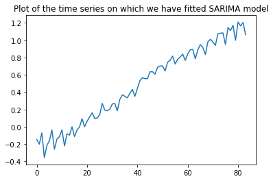

```python
plt.title('Plot of the time series on which we have fitted SARIMA model')
plt.plot(logx)
plt.show()
```

## Forecasting using Simple Exponential Smoothing

```
Figure 7.1: Oil production in Saudi Arabia from 1996 to 2007.
```

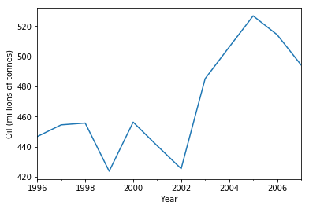

```python
from statsmodels.tsa.api import ExponentialSmoothing, SimpleExpSmoothing, Holt

%matplotlib inline

data = [
    446.6565,
    454.4733,
    455.663,
    423.6322,
    456.2713,
    440.5881,
    425.3325,
    485.1494,
    506.0482,
    526.792,
    514.2689,
    494.211,
]
index = pd.date_range(start="1996", end="2008", freq="A")
oildata = pd.Series(data, index)
ax = oildata.plot()
ax.set_xlabel("Year")
ax.set_ylabel("Oil (millions of tonnes)")
print("Figure 7.1: Oil production in Saudi Arabia from 1996 to 2007.")
```

```python
oildata
```

```
1996-12-31    446.6565
1997-12-31    454.4733
1998-12-31    455.6630
1999-12-31    423.6322
2000-12-31    456.2713
                ...
2003-12-31    485.1494
2004-12-31    506.0482
2005-12-31    526.7920
2006-12-31    514.2689
2007-12-31    494.2110
Freq: A-DEC, Length: 12, dtype: float64
```

Here we run three variants of simple exponential smoothing:

1. In fit1 we do not use the auto optimization but instead choose to explicitly provide the model with the parameter $\alpha=0.2$
2. In fit2 as above we choose an $\alpha=0.6$
3. In fit3 we allow statsmodels to automatically find an optimized $\alpha$ value for us. This is the recommended approach.

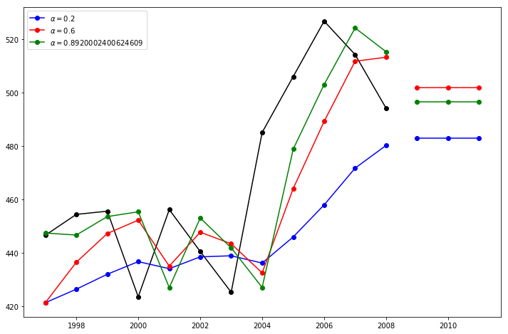

```python
fit1 = SimpleExpSmoothing(oildata, initialization_method="heuristic").fit(
    smoothing_level=0.2, optimized=False
)
fcast1 = fit1.forecast(3).rename(r"$\alpha=0.2$")
fit2 = SimpleExpSmoothing(oildata, initialization_method="heuristic").fit(
    smoothing_level=0.6, optimized=False
)
fcast2 = fit2.forecast(3).rename(r"$\alpha=0.6$")
fit3 = SimpleExpSmoothing(oildata, initialization_method="estimated").fit()
fcast3 = fit3.forecast(3).rename(r"$\alpha=%s$" % fit3.model.params["smoothing_level"])

plt.figure(figsize=(12, 8))
plt.plot(oildata, marker="o", color="black")
plt.plot(fit1.fittedvalues, marker="o", color="blue")
(line1,) = plt.plot(fcast1, marker="o", color="blue")
plt.plot(fit2.fittedvalues, marker="o", color="red")
(line2,) = plt.plot(fcast2, marker="o", color="red")
plt.plot(fit3.fittedvalues, marker="o", color="green")
(line3,) = plt.plot(fcast3, marker="o", color="green")
plt.legend([line1, line2, line3], [fcast1.name, fcast2.name, fcast3.name])
plt.show()
```